# Figure 2 and associated supplementary figures

# Figure 2

```r
data = data_all %>% filter(Method == "ABC-SMC" & n_presim=="10000") %>%
  bind_rows(data_all %>% filter(n_presim == "100000" & flow_type == "NSF")) %>%
  unite(mod_method, Model, Method, sep = " ", remove=F) %>%
  unite(sim_params,s_real, mu_real, remove = F)

color_vec = c("#4daf4a", "#984ea3","#e41a1c", "#377eb8", "black")
mod_meth = c("Chemo NPE", "WF NPE", "Chemo ABC-SMC", "WF ABC-SMC", "Pseudo-observation")

labs <- c("s relative error", expression(paste(delta," relative error")), "Total relative error")
names(labs) <- c("relative_error_s", "relative_error_mut", "total_rel_error")

hdr_data_long = hdr_data %>%
  filter(method == "ABC-SMC" & n_presim=="100") %>% #& rep == "1"
  bind_rows(hdr_data %>% filter(n_presim == 100000 & flow_type == "NSF")) %>% #& rep == 1
  unite(mod_method, model, method, sep = " ", remove=F) %>%
  pivot_longer(cols = starts_with("0."), names_to = "sim_params", values_to = "in_hdr")
```

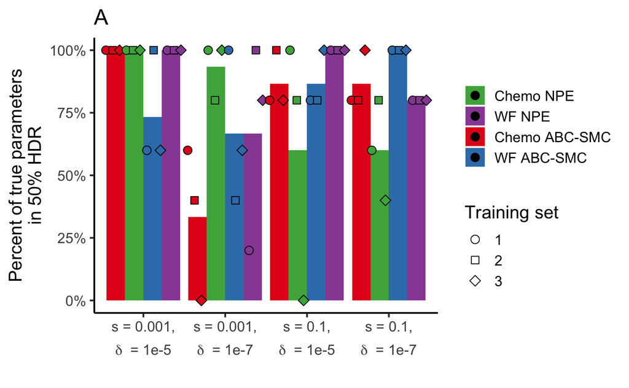

```r
a2 = hdr_data_long %>% mutate(in_hdr_prop = in_hdr/5) %>%
  group_by(mod_method, sim_params) %>%
  summarize(mean_in_hdr_prop = mean(in_hdr_prop)) %>%#*100) %>%
  ggplot(aes(sim_params, mean_in_hdr_prop,fill=mod_method)) +#, shape = as.factor(rep))) +
  #geom_boxplot() +
  geom_bar(stat="identity", position="dodge") +
  geom_point(data=hdr_data_long %>% mutate(in_hdr_prop = in_hdr/5),
             aes(sim_params, in_hdr_prop,fill=mod_method,shape = as.factor(rep)),
             color="black",
             position = position_dodge2(width = 1),
             size=3) +
  scale_fill_manual(values=color_vec,name="", breaks=mod_meth) +
  scale_shape_manual(values = c(21, 22, 23), name = "Training set") +
  xlab("") +
  ylab("Percent of true parameters\nin 50% HDR") +
  scale_y_continuous(labels = scales::percent) +#, limits = c(0,100)) +
  ggtitle("A") +
  scale_x_discrete(labels=c("0.001_1e-7"  = expression(atop("s = 0.001,", paste(delta, "  = 1e-7"))),
                                                                                  "0.001_1e-5" = expression(atop("s = 0.001,", paste(delta, "  = 1e-5"))),
                                                                                  "0.1_1e-7"  = expression(atop("s = 0.1,", paste(delta, "  = 1e-7"))),
                                                                                  "0.1_1e-5"  = expression(atop("s = 0.1,", paste(delta, "  = 1e-5")))))
a2
```

*A)* Percentage of true parameters within the 50% HDR. For NPE, each training set corresponds to an independent amortized posterior trained with 100,000 simulations, with which each observation was evaluated. For ABC-SMC, each training set corresponds to independent inference procedures on each observation using a total simulation budget of 100,000 and the stopping criteria of 10 rounds or ε <= 0.002. The bar height shows the average of three training sets.

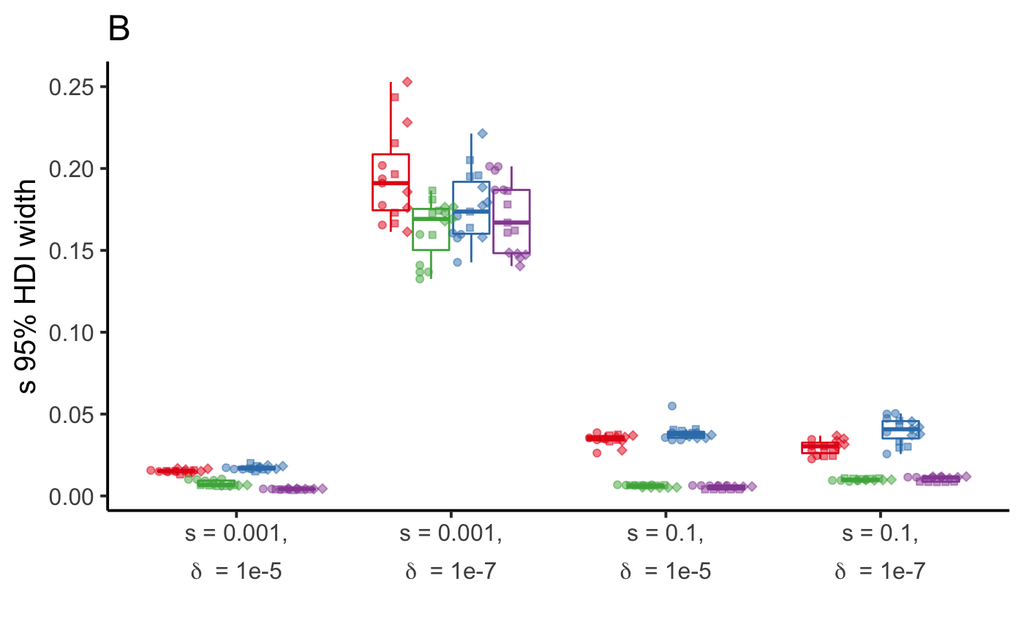

```r
b2 = data %>% mutate(fit_hdi_width= 10^fit_95hdi_high - 10^fit_95hdi_low) %>%
  ggplot(aes(sim_params, fit_hdi_width, color = mod_method))  +
  geom_boxplot(outlier.shape = NA, position = position_dodge2(width=1))+
  scale_color_manual(values=color_vec,
                     name="",
                     breaks=mod_meth) +
  geom_beeswarm(aes(fill=mod_method, shape = as.factor(presim_rep)), dodge.width = .7, alpha = 0.5) +#,dodge.width = 1, size=1, cex=3, shape = 21, color="black") +
  #geom_point(aes(fill=mod_method,shape = as.factor(presim_rep)),
    #         color="black",
     #        position = position_dodge2(width = 0.7),
      #       size=1.5) +
  scale_shape_manual(values = c(21, 22, 23), name = "Training set") +
  scale_fill_manual(values=color_vec,
                     name="",
                     limits=mod_meth, guide = 'none') +
  ylab("s 95% HDI width") +
  xlab("") +
  theme(legend.position = "none") +
  scale_x_discrete(labels=c("0.001_1e-07"  = expression(atop("s = 0.001,", paste(delta, "  = 1e-7"))),
                            "0.001_1e-05" = expression(atop("s = 0.001,", paste(delta, "  = 1e-5"))),
                            "0.1_1e-07"  = expression(atop("s = 0.1,", paste(delta, "  = 1e-7"))),
                            "0.1_1e-05"  = expression(atop("s = 0.1,", paste(delta, "  = 1e-5"))))) +
  ggtitle("B")
b2
```

*B)* Distribution of widths of the fitness effect s 95% highest density interval (HDI) calculated as the difference between the 97.5 percentile and 2.5 percentile, for each inferred posterior distribution.

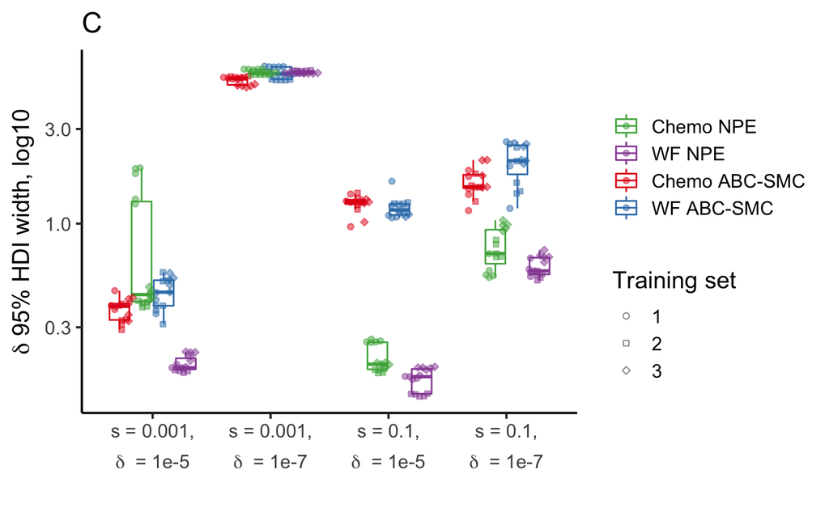

```r
c2 = data %>%
  mutate(mut_hdi_width= mut_95hdi_high - mut_95hdi_low) %>%
  ggplot(aes(sim_params, mut_hdi_width, color = mod_method)) +
  geom_boxplot(outlier.shape = NA, position = position_dodge2(width=1))+
  scale_color_manual(values=color_vec,
                     name="",
                     breaks=mod_meth) +
  geom_beeswarm(aes(fill=mod_method, shape = as.factor(presim_rep)), dodge.width = .7, alpha = 0.5) +
  scale_shape_manual(values = c(21, 22, 23), name = "Training set") +
  scale_fill_manual(values=color_vec,
                    name="",
                    limits=mod_meth, guide = 'none') +
  scale_y_log10() +
  ylab(expression(paste(delta," 95% HDI width, log10"))) +
  xlab("") +
  scale_x_discrete(labels=c("0.001_1e-07"  = expression(atop("s = 0.001,", paste(delta, "  = 1e-7"))),
                            "0.001_1e-05" = expression(atop("s = 0.001,", paste(delta, "  = 1e-5"))),
                            "0.1_1e-07"  = expression(atop("s = 0.1,", paste(delta, "  = 1e-7"))),
                            "0.1_1e-05"  = expression(atop("s = 0.1,", paste(delta, "  = 1e-5"))))) +
  ggtitle("C")
c2
```

*C)* Distribution of the number of orders of magnitude encompassed by the mutation rate 𝛿 95% HDI, calculated as difference of the base 10 logarithms of the 97.5 percentile and 2.5 percentile, for each inferred posterior distribution